# 1 Question: How does education level vary with type of employment?

## 1.1 Prepare data

**Loading the libraries**

```r
library(dplyr)
library(ggplot2)
library(RColorBrewer)
```

**Reading the data file**

```r
data <- read.csv("zp_merged_data.csv")
```

**Extracting only the necessary data**

```r
selected_data <- data %>%
  select(
    -CURROCCUPATIONISCO,
    -HIGHESTCOMPLEDUAGGI,
    -CURRACTIVITY_HOME,
    -CURRACTIVITY_PART,
    -CURRACTIVITY_FULL
  )
head(selected_data)
```

```
##   CURRACTIVITYSTATUSIII IN_EDUCATION HIGHESTCOMPLEDU AGE SEX
## 1                     1            0              11  46   1
## 2                     4            1               9  24   2
## 3                     1            0              12  39   1
## 4                     8            0               7  65   1
## 5                     6            1               3  18   1
## 6                     1            0               2  46   1
```

### 1.1.1 Decoding the data

**This code transforms a dataset by creating and modifying variables, making it ready for analysis**

```r
decoded_data <- selected_data %>%
  mutate(
    IN_EDUCATION = recode(as.factor(IN_EDUCATION),
                          "0" = "Not In Education",
                          "1" = "In Education"),

    CURRACTIVITYSTATUSIII = case_when(
      CURRACTIVITYSTATUSIII == "1" ~ "Full Time",
      CURRACTIVITYSTATUSIII %in% c("2", "3", "4") ~ "Part Time",
      TRUE ~ "Unemployed"
    ),

    HIGHESTCOMPLEDU = recode(as.factor(HIGHESTCOMPLEDU),
                             "1" = "None",
                             "2" = "Compulsory",
                             "3" = "Compulsory",
                             "4" = "Secondary",
                             "5" = "Secondary",
                             "6" = "Basic VET",
                             "7" = "Secondary",
                             "8" = "Secondary",
                             "9" = "Higher VET",
                             "10" = "Higher VET",
                             "11" = "Higher Ed",
                             "12" = "Higher Ed",
                             "13" = "Higher Ed"
    )
  ) %>%
  mutate(Employment_Type = as.factor(CURRACTIVITYSTATUSIII))



decoded_data$AGE <- cut(
  selected_data$AGE,
  breaks = c(15, 22, 29, 46, 56, Inf),
  right = FALSE,
  labels = c("Teen", "Young Adult", "Adult", "Mature Adult", "Mature Adult")
)
```

**Summary of missing values and levels**

```r
summary_cleaned_data <- lapply(decoded_data, function(x) {
  list(
    MissingValues = sum(is.na(x)),
    Levels = if (is.factor(x)) levels(x) else NULL
  )
})
print(summary_cleaned_data)
```

```
## $CURRACTIVITYSTATUSIII
## $CURRACTIVITYSTATUSIII$MissingValues
## [1] 0
##
## $CURRACTIVITYSTATUSIII$Levels
## NULL
##
##
## $IN_EDUCATION
## $IN_EDUCATION$MissingValues
## [1] 0
##
## $IN_EDUCATION$Levels
## [1] "-10"              "Not In Education" "In Education"
##
##
## $HIGHESTCOMPLEDU
## $HIGHESTCOMPLEDU$MissingValues
## [1] 0
##
## $HIGHESTCOMPLEDU$Levels
## [1] "-9"         "None"       "Compulsory" "Secondary"  "Basic VET"
## [6] "Higher VET" "Higher Ed"
##
##
## $AGE
## $AGE$MissingValues
## [1] 0
##
## $AGE$Levels
## [1] "Teen"         "Young Adult"  "Adult"        "Mature Adult"
##
##
## $SEX
## $SEX$MissingValues
## [1] 0
##
## $SEX$Levels
## NULL
##
##
## $Employment_Type
## $Employment_Type$MissingValues
## [1] 0
##
## $Employment_Type$Levels
## [1] "Full Time"  "Part Time"  "Unemployed"
```

```r
str(decoded_data)
```

```
## 'data.frame':    2803790 obs. of  6 variables:
##  $ CURRACTIVITYSTATUSIII: chr  "Full Time" "Part Time" "Full Time" "Unemployed" ...
##  $ IN_EDUCATION         : Factor w/ 3 levels "-10","Not In Education",..: 2 3 2 2 3 2 2 3 2 2 ...
##  $ HIGHESTCOMPLEDU      : Factor w/ 7 levels "-9","None","Compulsory",..: 7 6 7 4 3 3 7 5 3 5 ...
##  $ AGE                  : Factor w/ 4 levels "Teen","Young Adult",..: 4 2 3 4 1 4 4 1 2 4 ...
##  $ SEX                  : int  1 2 1 1 1 1 1 2 1 2 ...
##  $ Employment_Type      : Factor w/ 3 levels "Full Time","Part Time",..: 1 2 1 3 3 1 1 1 1 3 ...
```

### 1.1.2 Filter and Clean Data

**This code filters out invalid and missing values and drops unused factor levels.The result is stored in cleaned_data for analysis.**

```r
clean_data <- decoded_data %>%
  mutate(across(where(is.factor), as.character)) %>%
  filter(if_all(everything(), ~ . != "-9" & . != "-10" & !is.na(.))) %>%
  mutate(across(where(is.character), as.factor))
```

**checking variables**

```r
str(clean_data)
```

```
## 'data.frame':    2789311 obs. of  6 variables:
##  $ CURRACTIVITYSTATUSIII: Factor w/ 3 levels "Full Time","Part Time",..: 1 2 1 3 3 1 1 1 1 3 ...
##  $ IN_EDUCATION         : Factor w/ 2 levels "In Education",..: 2 1 2 2 1 2 2 1 2 2 ...
##  $ HIGHESTCOMPLEDU      : Factor w/ 6 levels "Basic VET","Compulsory",..: 3 4 3 6 2 2 3 1 2 1 ...
##  $ AGE                  : Factor w/ 4 levels "Adult","Mature Adult",..: 2 4 1 2 3 2 2 3 4 2 ...
##  $ SEX                  : int  1 2 1 1 1 1 1 2 1 2 ...
##  $ Employment_Type      : Factor w/ 3 levels "Full Time","Part Time",..: 1 2 1 3 3 1 1 1 1 3 ...
```

## 1.2 Plots

### 1.2.1 The most frequent education/employment level

**What is the most commonly completed education level and the most common employment type among different generations?**

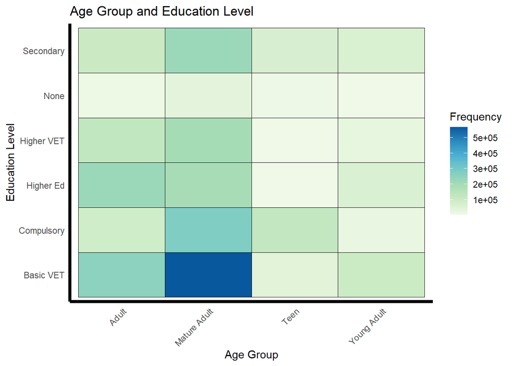

```r
heatmap_data <- clean_data %>%
  count(AGE, HIGHESTCOMPLEDU)
ggplot(heatmap_data, aes(x = AGE, y = HIGHESTCOMPLEDU, fill = n)) +
  geom_tile(color = "black") +
  scale_fill_distiller(palette = "GnBu", direction = 1) +
  labs(
    title = "Age Group and Education Level",
    x = "Age Group",
    y = "Education Level",
    fill = "Frequency"
  ) +
  theme_minimal() +
  theme(
    axis.text.x = element_text(angle = 45, hjust = 1),
    axis.line = element_line(color = "black", size = 1.5),
    panel.grid = element_blank()
  )
```

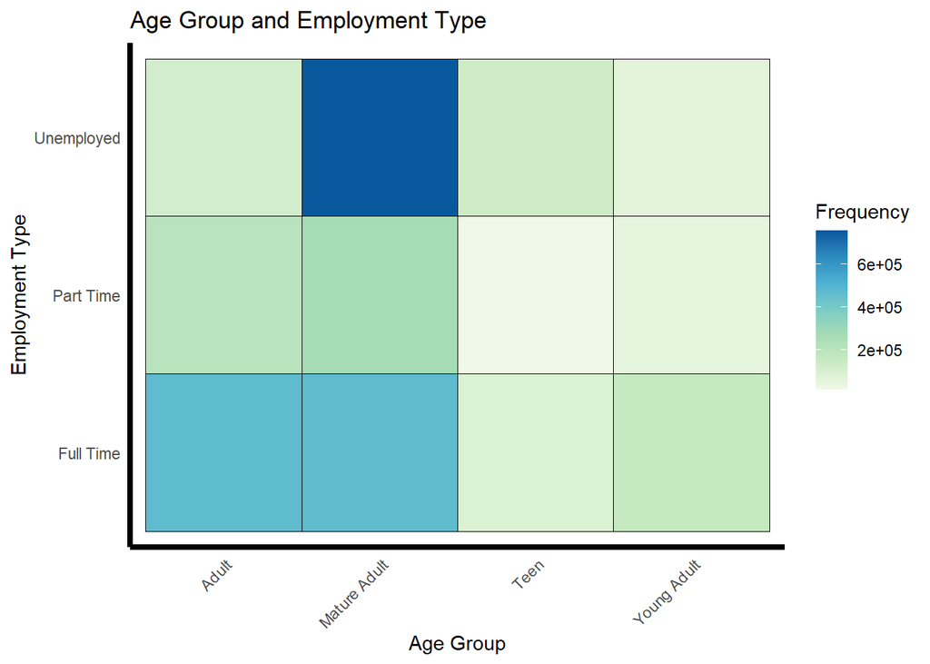

```r
heatmap_data <- clean_data %>%
  count(AGE, Employment_Type)

ggplot(heatmap_data, aes(x = AGE, y = Employment_Type, fill = n)) +
  geom_tile(color = "black") +
  scale_fill_distiller(palette = "GnBu", direction = 1) +
  labs(
    title = "Age Group and Employment Type",
    x = "Age Group",
    y = "Employment Type",
    fill = "Frequency"
  ) +
  theme_minimal() +
  theme(
    axis.text.x = element_text(angle = 45, hjust = 1),
    axis.line = element_line(color = "black", size = 1.5),
    panel.grid = element_blank()
  )
```

**People start to concentrate on work when they reach 30 Year Age.**

**People mostly prefer to work Full-Time**